# Project 2: Data Preparation & Transformation Pt. III

Albert Gilharry

March 8, 2018

## Data Set III - Child Mortality

This data set was posted by **Raj Kumar**. Childmortality.org is an organization that publishes Child Mortality estimates for all the countries around the world. They provide all available data and the latest child mortality estimates for each country based on the research of the UN Inter-agency Group for Child Mortality Estimation.

The data is in a very wide format and contains six variables with values of interest. Each of these variables are concatinated to each year from 1950 to 2016, resulting in 405 columns. These key variables are

Under-5 (0-4 years) mortality Infant (0-1 years) mortality Neonatal (0-1 month) mortality Number of under-5 deaths Number of infant deaths Number of neonatal deaths

As suggested by Raj, We can read this data into a data frame and subset the data set to the median estimate for each country. We need to also handle null values of the data. Then we can convert this data into long format with 4 variables country, year, category and their respective value. This will make it easier to analyze the data."

My goals with this data set are as follows:

(-) **Load, Tidy, and transform the data.**  
(-) **Map Infant Mortality Rate across the globe.**  
(-) **Map and compare the change in Infant Mortality Rates**  
(-) **Create time series plots of Infant Mortality for the extremes.**

## Load Libraries

```r
library("tidyverse")
library("stringr")
library("DT")
library("rworldmap")
```

## Load Data

```r
data <- read.csv("data/ChildMortality.csv", sep = ",", header = TRUE, stringsAsFactors = FALSE)
```

## Preview Data Structure

```r
str(data)
```

```
## 'data.frame':    585 obs. of  405 variables:
##  $ ISO.Code              : chr  "AFG" "AFG" "AFG" "AGO" ...
##  $ CountryName           : chr  "Afghanistan" "Afghanistan" "Afghanistan" "Angola" ...
##  $ Uncertainty.bounds.   : chr  "Lower" "Median" "Upper" "Lower" ...
##  $ U5MR.1950             : num  NA NA NA NA NA NA NA NA NA NA ...
##  $ U5MR.1951             : num  NA NA NA NA NA NA NA NA NA NA ...
##  $ U5MR.1952             : num  NA NA NA NA NA NA NA NA NA NA ...
##  $ U5MR.1953             : num  NA NA NA NA NA NA NA NA NA NA ...
##  $ U5MR.1954             : num  NA NA NA NA NA NA NA NA NA NA ...
##  $ U5MR.1955             : num  NA NA NA NA NA NA NA NA NA NA ...
##  $ U5MR.1956             : num  NA NA NA NA NA NA NA NA NA NA ...
##  $ U5MR.1957             : num  NA NA NA NA NA NA NA NA NA NA ...
##  $ U5MR.1958             : num  NA NA NA NA NA NA NA NA NA NA ...
##  $ U5MR.1959             : num  NA NA NA NA NA NA NA NA NA NA ...
##  $ U5MR.1960             : num  308 364 427 NA NA ...
```

[output cut: 86 more lines]

The structure reveals a data set with 405 variables. Variables in the form `Under.five.Deaths.1955` will pose a problem for analysis because it represents two variables, category and year.

1. Use the `gather` function to convert variables of the form `variable.name.year` to rows. This should result in a variable called `YearCat` (preserving the current format), and variable called `Rate`.

```r
data <- gather(data, "YearCat", "Rate", 4:405)
```

2. Split the `YearCat`variable into `Category` and `Year`.

```r
data$Category <- str_sub(data$YearCat,1,-6)
data$Year <- strtoi(str_sub(data$YearCat, -4))
datatable( tail(data), options = list(filter = FALSE),filter="none" )
```

|  | ISO.Code | CountryName | Uncertainty.bounds. | YearCat | Rate | Category | Year |
| --- | --- | --- | --- | --- | --- | --- | --- |
| 235165 | ZMB | Zambia | Lower | Neonatal.Deaths.2016 | 10239 | Neonatal.Deaths | 2016 |
| 235166 | ZMB | Zambia | Median | Neonatal.Deaths.2016 | 14505 | Neonatal.Deaths | 2016 |
| 235167 | ZMB | Zambia | Upper | Neonatal.Deaths.2016 | 19954 | Neonatal.Deaths | 2016 |
| 235168 | ZWE | Zimbabwe | Lower | Neonatal.Deaths.2016 | 9264 | Neonatal.Deaths | 2016 |
| 235169 | ZWE | Zimbabwe | Median | Neonatal.Deaths.2016 | 12246 | Neonatal.Deaths | 2016 |
| 235170 | ZWE | Zimbabwe | Upper | Neonatal.Deaths.2016 | 15952 | Neonatal.Deaths | 2016 |

## Analysis

3. Map the Infant Mortality Rate for the year 1980 and, 2016, using the median.

```r
# filter the data to match criteria
mdata <- filter(data, `Category` == "IMR", `Uncertainty.bounds.` == "Median", Year == 1980)

# match country polygon to country code in data set
sPDF <- joinCountryData2Map( mdata,joinCode = "ISO3", nameJoinColumn = "ISO.Code")
```

```
## 195 codes from your data successfully matched countries in the map
## 0 codes from your data failed to match with a country code in the map
## 48 codes from the map weren't represented in your data
```

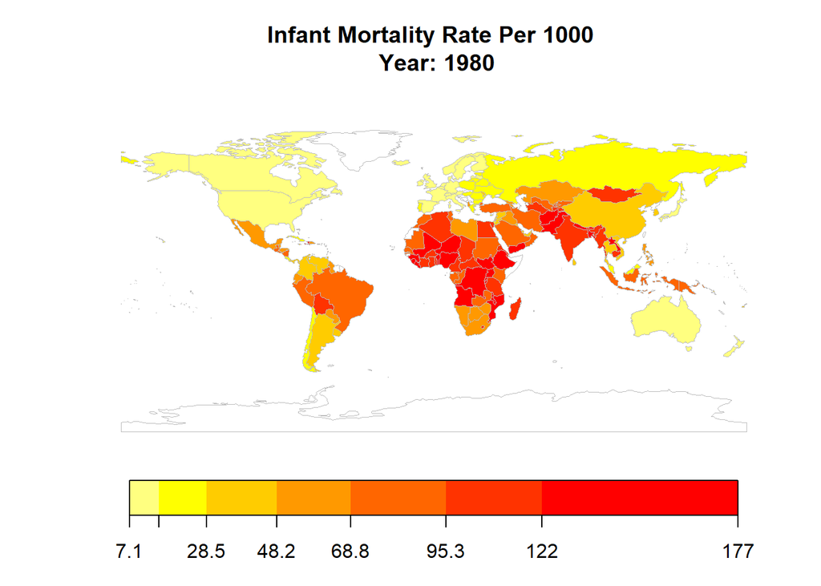

```r
mapParams <- mapCountryData(sPDF,nameColumnToPlot='Rate',
                            missingCountryCol = NA,
                            addLegend ='FALSE',
                            mapTitle = "Infant Mortality Rate Per 1000 \n Year: 1980")

do.call( addMapLegend, c( mapParams, legendLabels = "all", legendWidth = 1.5 ) )
```

```r
# filter the data to match criteria
mdata <- filter(data, `Category` == "IMR", `Uncertainty.bounds.` == "Median", Year == 2016)

# match country polygon to country code in data set
sPDF <- joinCountryData2Map( mdata,joinCode = "ISO3", nameJoinColumn = "ISO.Code")
```

```
## 195 codes from your data successfully matched countries in the map
## 0 codes from your data failed to match with a country code in the map
## 48 codes from the map weren't represented in your data
```

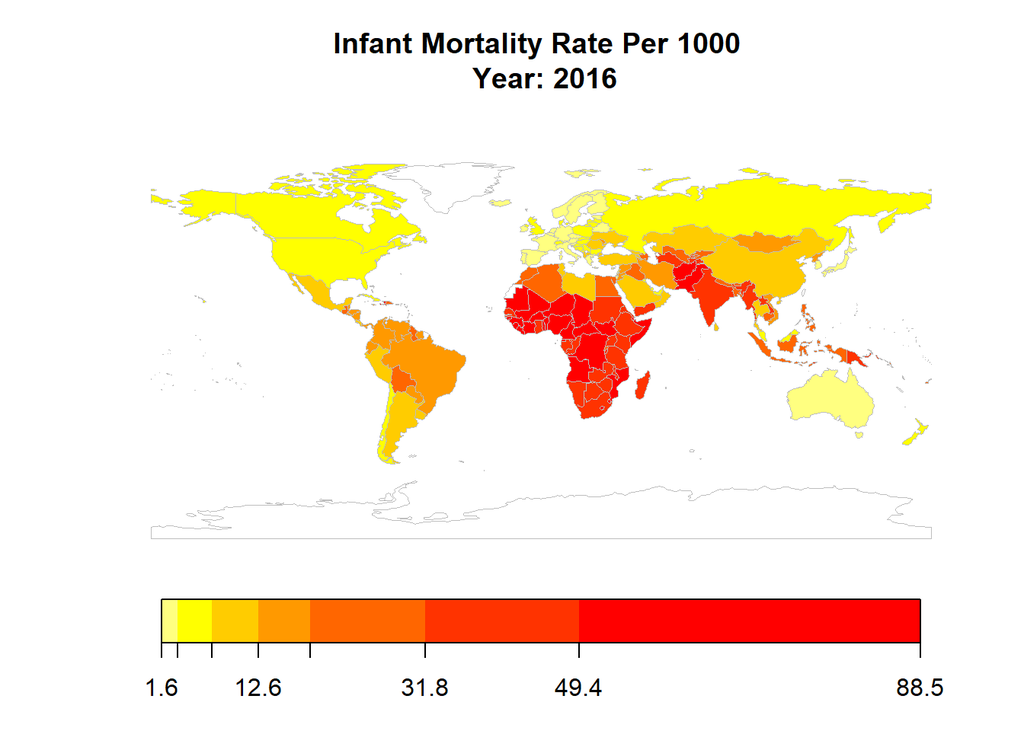

```r
mapParams <- mapCountryData(sPDF,nameColumnToPlot='Rate',
                            missingCountryCol = NA,
                            addLegend ='FALSE',
                            mapTitle = "Infant Mortality Rate Per 1000 \n Year: 2016")

do.call( addMapLegend, c( mapParams, legendLabels = "all", legendWidth = 1.5 ) )
```

The maps show a stunning decrease in Infant Mortality Rates from 1980 to 2016. This is evident by looking at the scales, where the both minimum and maximum values decreased from 7.1 to 1.6 and 177 to 88.5 respectively. Africa is still plagued by relatively high infant mortaility rates after all those years.

Europe, North America (excluding Mexico), Russia, and Australia have lowest rates. China is the only “world power” with questionable Infant Mortality Rates.

4. What about the change in Infant Mortality Rates accross the same time period?

```r
# calculate the difference in IMR between 1980 and 2016
mData <- select(data, -YearCat) %>%
          filter( `Category` == "IMR", `Uncertainty.bounds.` == "Median", Year == 1980 | Year == 2016  ) %>%
          spread( Year, Rate )  %>%
          mutate( ISO.Code = ISO.Code, Rate =  `1980` - `2016` )

# match country polygon to country code in data set
sPDF <- joinCountryData2Map( data.frame(mData),joinCode = "ISO3", nameJoinColumn = "ISO.Code" )
```

```
## 195 codes from your data successfully matched countries in the map
## 0 codes from your data failed to match with a country code in the map
## 48 codes from the map weren't represented in your data
```

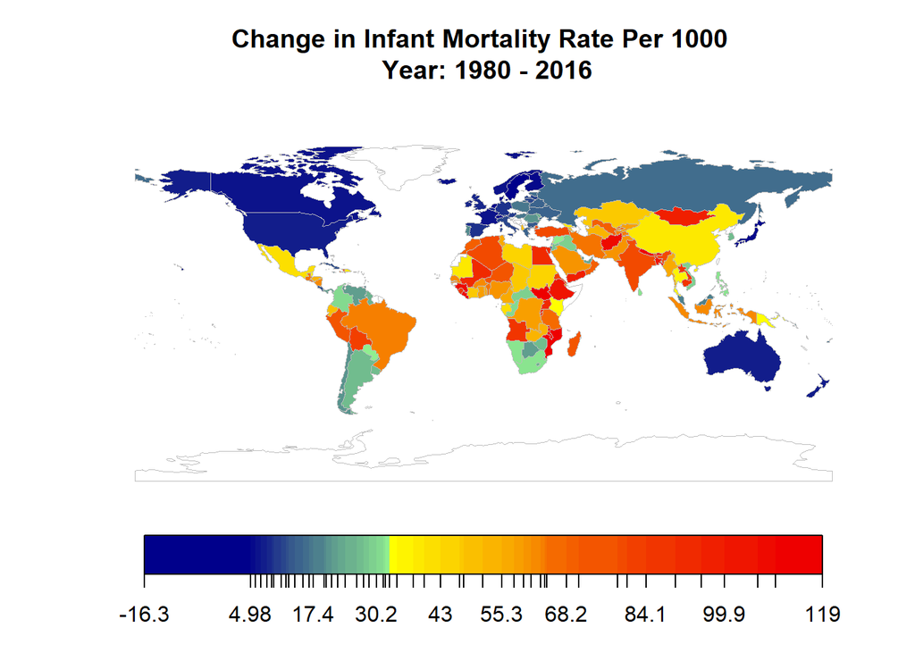

```r
mapParams <- mapCountryData(sPDF,nameColumnToPlot='Rate',
                            numCats = 50,
                            missingCountryCol = NA,
                            colourPalette = 'diverging',
                            addLegend ='FALSE',
                            mapTitle = "Change in Infant Mortality Rate Per 1000 \n Year: 1980 - 2016")

do.call( addMapLegend, c( mapParams, legendLabels = "all", legendWidth = 1.5 ) )
```

The map shows that the highest decreases in Infant Mortality Rates were in countries with previously very high rates. These are concentrated in Africa and the Middle-East. However, the map does a poor a job of displaying countries with increases in Infant Mortality Rates. The map legend suggests that at least one country had an increase in Infant Mortality of 16.3.

5. Which countries had an increase in Infant Mortaility Rate from 1980 to 2016?

```r
datatable(filter(mData, Rate < 0 ), options = list(filter = FALSE),filter="none")
```

|  | ISO.Code | CountryName | Uncertainty.bounds. | Category | 1980 | 2016 | Rate |
| --- | --- | --- | --- | --- | --- | --- | --- |
| 1 | DMA | Dominica | Median | IMR | 14.9 | 31.2 | -16.3 |

**Dominica is the only country that had a higher Infant Mortality Rate in 2016 when compared to 1980!**

6. Plot a times series chart for Infant Mortality Rate for the country with the highest and lowest increase over the period.

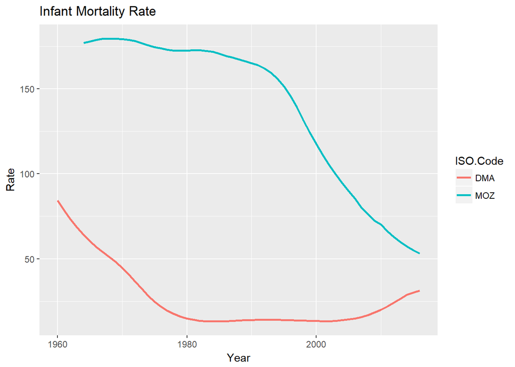

```r
pData <- filter(data,
                `ISO.Code` == arrange( mData, `Rate` )$`ISO.Code`[1] | `ISO.Code` == arrange( mData, desc( `Rate` ) )$`ISO.Code`[1],
                `Category` == "IMR",
                `Uncertainty.bounds.` == "Median",
                !is.na(`Rate`) )
                ggplot( pData, aes(x = Year, y = Rate) ) +
                labs( title = "Infant Mortality Rate" ) +
                geom_line( aes(color = `ISO.Code`), size = 1 )
```

The plots are almost the inverse of each other. Dominica’s rate stablilized in the 1980’s but began increasing at an alarming rate around 2005. Mozambique’s rate trended downwards throughout. Mozambique probabilty had the largest deacrease due to its very high initial rate

## Conclusion

Much more can be done with this dataset. It would be interesting to have some relating fincancial/economic and management data to guage the effectiveness of methodoligies used to combat the issue of Infant Mortality.

Tools in the Tidyverse were particularly useful when this data set ballooned from 585 to over 200,000 observations.